# Analysis of Quinoa Seed Traits

Dataset: Lysine.14.mgG

Author

1066809

# 1 Dataset and libraries used for the analysis

```r
#Standard library
library(tidyverse)

#Data visualitzation
library(visdat)

#Table creation
library(knitr)

#Mutiple imputation
library(mice)

#MCAR test
library(naniar)

#Raw data analysis
data <- read.csv("https://raw.githubusercontent.com/biotechdesigner/quinoa-analysis-coursework/main/SM_Data.csv")

#Selected data for Lysine content, Yield and TSW
data1 <- data %>% select(Lysine.14.mgG, TSW, Yield_g)
selected_data <- arrange(data1, -Yield_g)

#Raw imputed data
imputed_data <- read.csv("https://raw.githubusercontent.com/biotechdesigner/quinoa-analysis-coursework/main/imputed_data.csv")
```

# 2 Data Description

The dataset contains measurements from 360 quinoa accessions, detailing various seed traits retreived from Craine et al. (2023). The data includes continuous measurements such as lysine content (measured in mg/g), yield (measured in g/plant) and Thousand Seed Weight, or TSW (measured in grams).

# 3 Analysis Description

This report presents an analysis of seed traits from a quinoa dataset consisting of 360 accessions. The analysis focuses specifically on the `Lysine.14.mgG` trait and its relationship with `yield` and thousand seed weight (`TSW`), although there are more phenotypic traits included in the dataset. An analysis of the dataset was made to tidy the data. Then, the missing values of the dataset were reported and the missing values were implanted using Multiple imputation (MI) using the Predictive Mean Matching method (PMM) because the MCAR (Missing Not At Random) test was made and resulted negative to the lysine content,the percentage of missing data on lysine content was above 10% and also to keep the statistical power of the analysis, so it reduces the chance of false-positive or false-negative conclusions. The article of Craine et al. (2023) eliminates the missing values completely of the analysis, but it should be useful to compare the correlation and distribution analysis with and without MI. PPM was used because imputations are based on values observed elsewhere, so they are realistic and is a recomended method when the data is Missing At Random (MAR) (Li, Stuart, and Allison 2015). Furthermore, a distribution plot of the `Lysine.14.mgG` trait was made with a normality test to see if the data is normally distributed using the Shapiro-Wilk test, which is common choice for normality testing due to its power and performance, particularly in moderate sample sizes like this one. Finally, a correlation and regression analysis was made between the `Lysine.14.mgG` trait and the `yield` and (`TSW`) separately using spearman correlation to account for the non-normal distribution of the data (Sarmento, n.d.). Additionaly, logaritmic values of the lysine content were used to try to normalize the data to some extent. These analysis were made to determine wether Lysine content in quinoa seeds is an influential factor to determine the yield and TSW.

## 3.1 Missing Data Assessment

Given the format of the missing values in the dataset (every missing data cell was filled with NA), the proportion of missing values of the traits of interest was visualized:

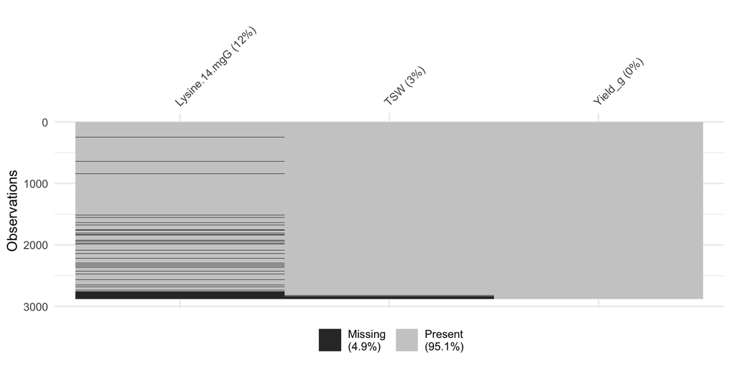

Figure 1: Graphic visualization and percantage of missing data from Yield, TSW and Lysine content

```r
vis_miss(selected_data, sort_miss = TRUE)
```

The analysis of missing data from table Figure 1 reveals 12% missing lysine content, 3% in TSW, and no yield data loss. Lee and Huber (2021) suggests using strategies like multiple imputation for increased and varied missing data for precise analyses. An MCAR analysis was performed to assess the feasibility of deleting columns with missing data.

```r
#mcar test
result <- mcar_test(selected_data)
kable(result, align = "llcr")
```

Table 1: MCAR test for Yield, TSW and Lysine content

| statistic | df | p.value | missing.patterns |
| --- | --- | --- | --- |
| 428.0913 | 5 | 0 | 4 |

The MCAR analysis results determined that the p-value is 0, rejecting the null hypothesis and indicating the data are not MCAR. Therefore, as per Bennett (2001), multiple imputation (MI) is recommended for proper data handling. This method will be used in the distribution (Section 3.2), correlation (Section 3.4), and regression (Section 3.5) analyses. Below is the code for generating the dataset with imputed values in CSV format [(See on GitHub)](https://github.com/biotechdesigner/quinoa-analysis-coursework/blob/main/imputed_data.csv). The project now refers to a new table with imputed data as `imputed_data`.

```r
#Using MICE library to do the MI using PPM
imputed_data <- mice(data[c("Yield_g", "TSW", "Lysine.14.mgG")], m=5, method='pmm')
completed_data <- complete(imputed_data, 1)

#create csv with the new imputed data:
write.csv(completed_data, "imputed_data.csv")
imputed_data <- read.csv("imputed_data.csv")
```

## 3.2 Frequency Distribution Analysis

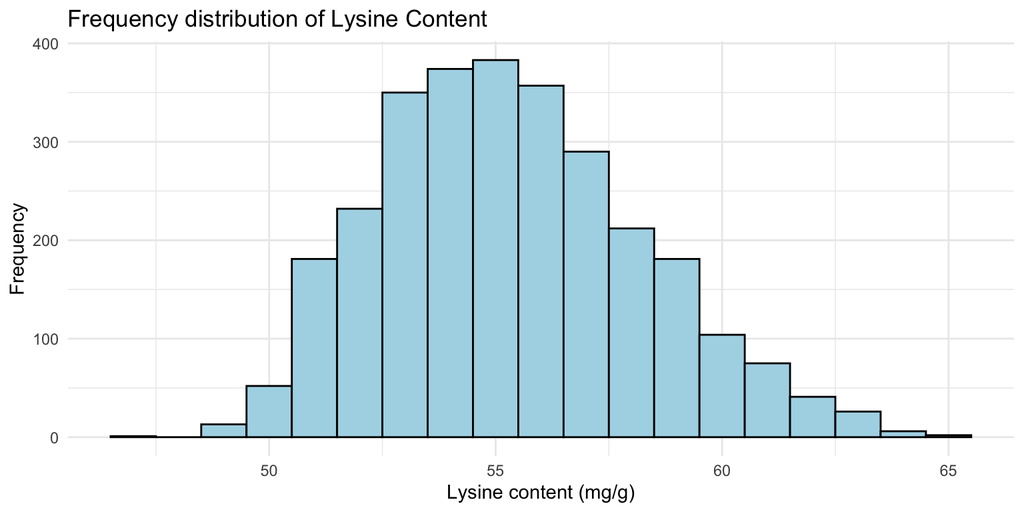

Figure 2: Histogram plot of the frequency distribution of Lysine content

```r
#Histogram plot code
ggplot(imputed_data, aes(x = Lysine.14.mgG)) +
  geom_histogram(binwidth = 1, fill = "lightblue", color = "black") +
  theme_minimal() +
  labs(title = "Frequency distribution of Lysine Content", x = "Lysine content (mg/g)", y = "Frequency")
```

From Figure 2, it is visually inferred that the data seems to be approximately normally distributed with a single peak and symmetric shape, however, it doesn´t follow exactly the bell curve, so it is needed to do a nromality test to make sure how the data is distributed.

## 3.3 Normality Test

```r
#Test for normal distribution
normality <- shapiro.test(imputed_data$Lysine.14.mgG)
result <- data.frame(
    W = normality$statistic,
    Pvalue = normality$p.value
)
kable(result, align = "llr")
```

Table 2: Shapiro_Wilk test results for lysine content

|  | W | Pvalue |
| --- | --- | --- |
| W | 0.9866363 | 0 |

The Shapiro-Wilk normality test has a p-value of almost 0 which is far below any conventional alpha level (e.g., 0.05). despite the high W value, the test finds significant evidence to suggest that the lysine content does not follow a normal distribution. For that reason, this will be needed to take into account the correlation and regression analyses.

## 3.4 Correlation analysis

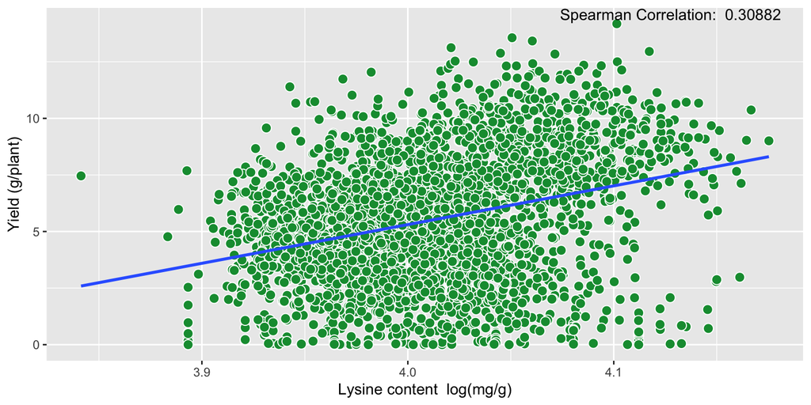

Figure 3: Correlation analysis between Lysine content and Yield traits

```r
#Add a column in imputed data with Lysine content transformed to logaritmic values
imputed_data$Lysine.14.mgG_log <- log(imputed_data$Lysine.14.mgG)

#Correlation analysis
cor_value_yield <- cor(imputed_data$Lysine.14.mgG_log, imputed_data$Yield_g, method = "spearman")

# Correlation plot
ggplot(imputed_data, aes(x = Lysine.14.mgG_log, y = Yield_g)) +
  geom_point(shape = 21, fill = '#0f993d', color = 'white', size = 3) +
  annotate("text", x = Inf, y = Inf, label = paste("Spearman Correlation: ", round(cor_value_yield, 5)),
           hjust = 1.1, vjust = 1.1) +
  geom_smooth(method = "lm", se = FALSE) +
  labs(x = "Lysine content  log(mg/g)", y = "Yield (g/plant)")
```